# Assignment 2

Kossi Akplaka

2023-09-17

```r
knitr::opts_chunk$set(eval = TRUE, message = FALSE, warning = FALSE)
library(tidyverse)
```

## Data

This is a summary of how I got the data and transform the data.

##### Using Google forms to gather the information.

I’ve asked some friends to rate 6 movies on the scale of 1 to 5 and leave blank if they haven’t seen the movie yet. The data was collected with Google forms. Here is the [link](https://forms.gle/jiZaGEf1KMg47kKz7) to the questions on the Google form.

##### Data manipulation

After data collection, we can now export the data into a csv file and use “NULL” as a placeholder for missing values.

##### Raw data location

The raw csv file is stored on my [github](https://github.com/Kossi-Akplaka/Data607-data_acquisition_and_management/blob/a3ab1039c3e2a90ea2a631c6d0e5a66f1057e91b/Assignment%202/Movie_Satifaction.csv).

## MySQL

Now, we can upload the survey data in mysql by:

- creating a new schema called “assignment2”.
- Then load the csv file in the table “movie_satifaction”.

#### Create R dataframe from mySQL

Let’s connect R to MySQL and retrieve the data set stored in a database table.

#### Install and load package RMySQL

```r
library('RMySQL')
```

#### Import data from MySQL

We can connect to the database using dbconnect. Also, I can hide the password when connecting to a MySQL database in R by storing the password securely outside your code.

Retrieve the MySQL password from the environment variable

```r
mysql_password <- Sys.getenv("MYSQL_PASSWORD")
```

Establish the database connection and query the database

```r
mydb = dbConnect(MySQL(), user='root',
                 password= mysql_password,
                 dbname='assignment2',
                 host='localhost')

movie_satifaction_survey <- dbGetQuery(mydb,
            "SELECT * FROM assignment2.movie_satifaction;")
```

Close the database connection when done

```r
dbDisconnect(mydb)
```

```
## [1] TRUE
```

let’s have a glimpse of the data

```r
glimpse(movie_satifaction_survey)
```

```
## Rows: 6
## Columns: 6
## $ Barbie             <dbl> 4, 1, NA, 4, 3, NA
## $ Oppenheimer        <dbl> 5, 3, NA, 3, 4, NA
## $ Spider_Man         <int> 4, 3, 5, 4, 4, NA
## $ Fast_X             <int> 4, 4, 3, 4, 1, 5
## $ Indiana_Jones      <dbl> 3, 3, NA, 5, 3, NA
## $ Mission_Impossible <int> 3, 4, 5, 5, 4, 4
```

## Is there any benefit in standardizing ratings?

- It is easier to compare the movies.
- It is easier to visualize the data (for instance, histograms of standardized ratings can reveal the distribution of ratings more clearly).

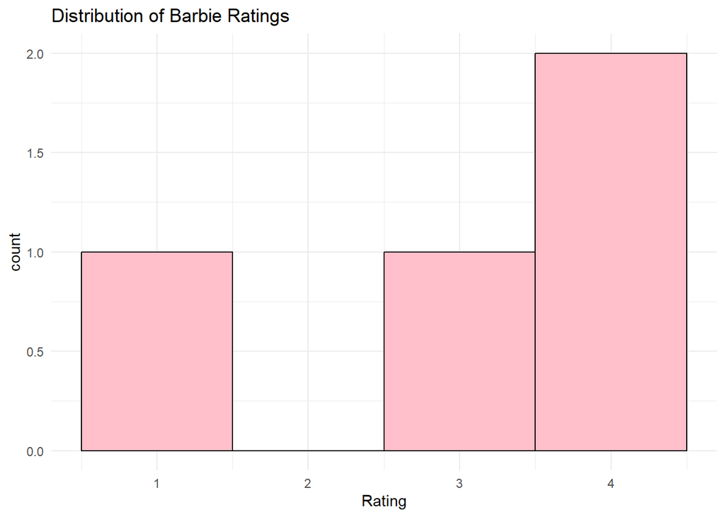

```r
ggplot(movie_satifaction_survey, aes(Barbie)) +
  geom_histogram(binwidth = 1, fill = "pink", color = "black") +
  labs(title = "Distribution of Barbie Ratings", x = "Rating") +
  theme_minimal()
```

We can see that at least 1/3 of the population gave a 4 star rating to Barbie.

## Handling missing data

Let’s try different ways to handle the missing data

#### Fill in the missing values with the mode rating for the respective movie.

Create a function to fill with mode

```r
calc_mode <- function(x){
  distinct_values <- unique(x)
  distinct_tabulate <- tabulate(match(x, distinct_values))
  distinct_values[which.max(distinct_tabulate)]
}
```

Fill missing values in all columns with the mode

```r
movie_satisfaction_survey_filled <- movie_satifaction_survey %>%
  mutate(across(everything(), ~replace_na(.x, calc_mode(.x))))
```

View the result

```r
glimpse(movie_satisfaction_survey_filled)
```

```
## Rows: 6
## Columns: 6
## $ Barbie             <dbl> 4, 1, 4, 4, 3, 4
## $ Oppenheimer        <dbl> 5, 3, 3, 3, 4, 3
## $ Spider_Man         <int> 4, 3, 5, 4, 4, 4
## $ Fast_X             <int> 4, 4, 3, 4, 1, 5
## $ Indiana_Jones      <dbl> 3, 3, 3, 5, 3, 3
## $ Mission_Impossible <int> 3, 4, 5, 5, 4, 4
```

Create a visualization to explore

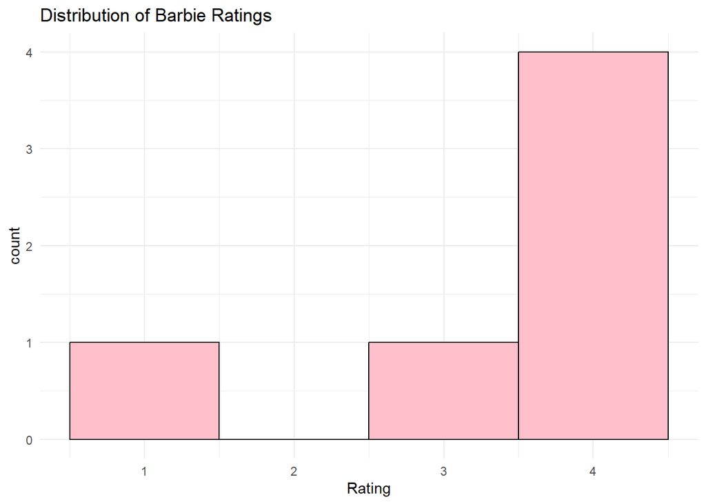

```r
ggplot(movie_satisfaction_survey_filled, aes(x = Barbie)) +
  geom_histogram(binwidth = 1, fill = "pink", color = "black") +
  labs(title = "Distribution of Barbie Ratings", x = "Rating") +
  theme_minimal()
```

Here, we can see that 2/3 of the population gave a 4 star to the Barbie movie. This shows that the way we handle missing values in the dataset can significantly impact the results and conclusions of your data analysis.

#### Next step: Fill in the missing values with the nearest neighbors.

I will work on an algorithm to fill the missing rating using the nearest neighbors.